# R data analysis pipeline

Author

Berry Boessenkool

This builds on the concepts from my [short course](https://github.com/brry/hour), look at that before this session!

## data info

Percentage of infants that are vaccinated per year and country. Data source: UNICEF Immunization coverage by antigen (country, regional, and global trends), see https://data.unicef.org/resources/dataset/immunization/ and the exact url

## packages

```r
if(!requireNamespace("pacman", quietly=TRUE)) install.packages("pacman")
pacman::p_load("berryFunctions", "vioplot")
```

## read data

Provided as a zip file containing txt files

- conditionally (if not already done), unzip it to a folder with a good name

```r
if(!dir.exists("vaccines")) unzip("vaccines.zip", exdir="vaccines")
```

- using `lapply` (or the `purr` equivalent), read the files with actual data

```r
filenames <- dir("vaccines", pattern="^vacc", full.names=TRUE)
names(filenames) <- sub(".txt","",sub("vaccines/vacc_","",filenames), fixed=TRUE)
vaccines <- lapply(filenames, read.table, header=TRUE, check.names=FALSE)
```

## convert to array

- convert the list to an array (see lesson 4.4 in the [full R course](https://bookdown.org/brry/course/), including the [exercise](https://open.hpi.de/courses/hpi-dh-fprog2024/items/2XsXVA2obqW2U4pjlNVrV)):

```r
countries <- read.delim("vaccines/countrycodes.txt") # iso3 countrycodes
arrayvacc <- lapply(vaccines, function(x)
 {
 # dimensions must be expanded to include all countries in all datasets:
 y <- merge(x, data.frame(iso3=countries$iso3), all=TRUE)
 y$iso3 <- NULL
 y
 })
arrayvacc <- berryFunctions::l2array(arrayvacc)
names(dimnames(arrayvacc)) <- c("country", "year", "vaccine")
dimnames(arrayvacc)[[1]] <- countries$iso3
```

## check data

EDA (exploratory data analysis)

- Are the data values in a reasonable range?

```r
str(arrayvacc)
```

```
 int [1:195, 1:43, 1:14] NA NA 93 NA 15 62 NA NA NA 90 ...
 - attr(*, "dimnames")=List of 3
  ..$ country: chr [1:195] "AFG" "AGO" "ALB" "AND" ...
  ..$ year   : chr [1:43] "1980" "1981" "1982" "1983" ...
  ..$ vaccine: chr [1:14] "BCG" "DTP1" "DTP3" "HEPB3" ...
```

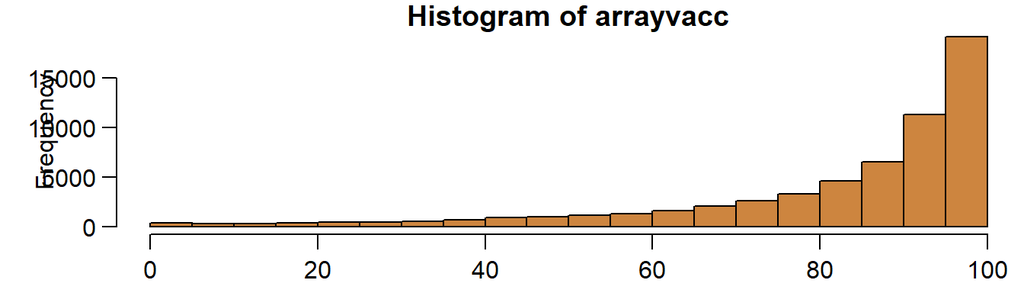

```r
hist(arrayvacc, col="tan3")
```

all values are 0-100 (percentage as per the metadata), higher percentages are more common

- Across all vaccines and countries, how many datapoints are available per year?

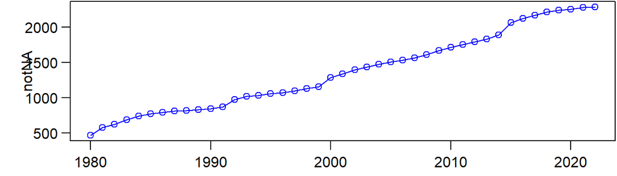

```r
notNA <- apply(arrayvacc, "year", function(v) sum(!is.na(v)) )
notNA <- colSums(!apply(arrayvacc, "year", is.na)) # alternative code
year <- as.numeric(names(notNA)) # will be used again below
plot(year, notNA, type="o", col="blue")
```

- For the year with most datapoints, visualize the distributions for each vaccine (histograms in a multipanel plot). Which vaccine has the largest variation among countries?

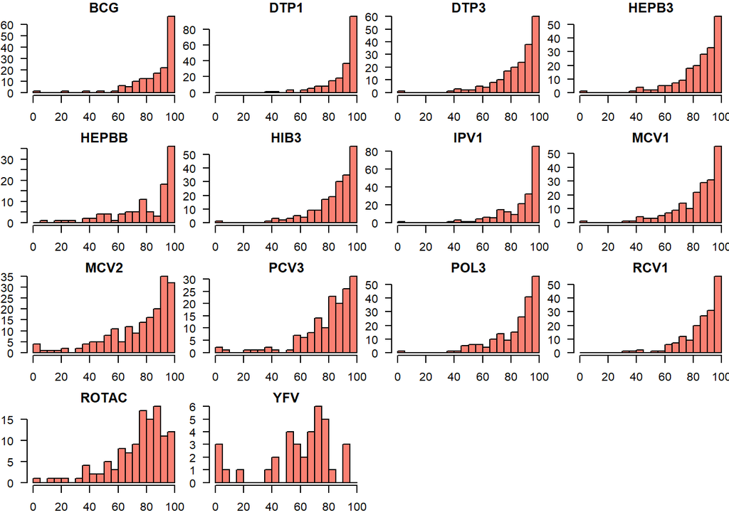

```r
## View(arrayvacc[,"2022",])
par(mfrow=c(4,4), mar=c(2.5,2,1,0.1), las=1)
hists <- sapply(dimnames(arrayvacc)$vaccine, function(v)
                  hist(arrayvacc[,"2022",v], main=v, breaks=seq(0,100,5), col="salmon"))
```

high variation: yellow fever -> not applicable in all countries

- For BCG, how does the distribution change over time?

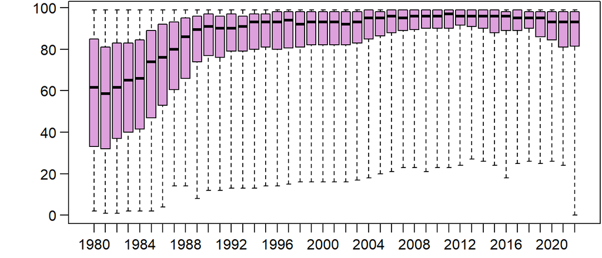

```r
boxplot(arrayvacc[,,"BCG"], range=0, col="plum")
```

## sanitize data

- As visible above, the BCG dataset has an anomaly in the last year (2022). How can you look at the raw data interactively?

```r
View(arrayvacc[,,"BCG"])
```

sort ascencingly/decreasingly to get a feel for the extremes

- What country is affected and does that happen for several vaccines?

```r
View(arrayvacc["PRK",,])
```

- How could you fix the issue?

Set PRK (North Korea) 2022 values that are zero to NA  
set all PRK 2022 values to NA  
ignore PRK completely (aggressive)

```r
arrayvacc["PRK","2022",] <- NA
arrayvacc <- arrayvacc[-which(rownames(arrayvacc)=="PRK"),,]
```

## visualize data

Visualize the temporal development of vaccinated infants for each vaccine. Consider how to display the individual countries:

- show aggregate + individual vaccines

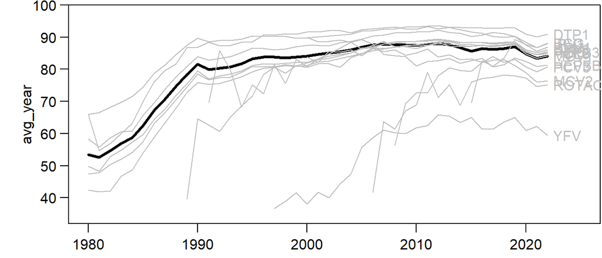

```r
avg_year <- apply(arrayvacc, "year", mean, na.rm=TRUE)
plot(year, avg_year, type="l", ylim=c(32,100), yaxs="i", xlim=c(1980,2025), lwd=3)
avg_yearvac <- apply(arrayvacc, "vaccine", colMeans, na.rm=T)
for(i in 1:14) lines(year, avg_yearvac[,i], col="grey")
text(2022.5, avg_yearvac["2022",], colnames(avg_yearvac), col="grey", adj=0)
```

- spaghetti plot with each country as a line

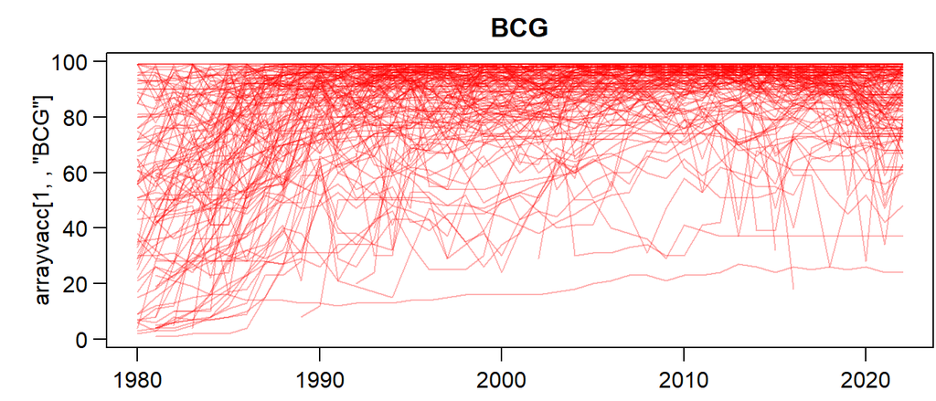

```r
plot(year, arrayvacc[1,,"BCG"], ylim=range(arrayvacc[,,"BCG"],na.rm=TRUE),
     type="n", main="BCG")
for(i in 1:nrow(arrayvacc)) lines(year, arrayvacc[i,,"BCG"],
                                  col=berryFunctions::addAlpha("red"))
```

- violin plots

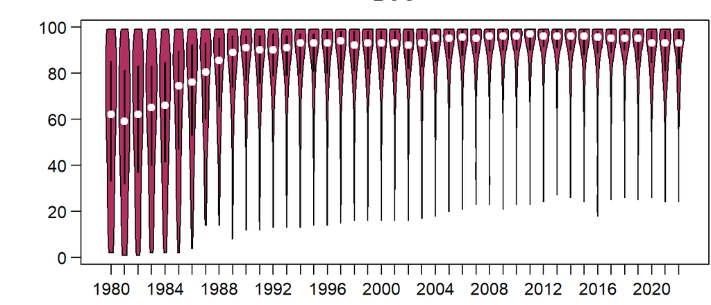

```r
vioplot::vioplot(arrayvacc[,,"BCG"], range=0, las=1, col="maroon", main="BCG")
```

(more granular than boxplots above)

- proportion of well-vaccinated countries

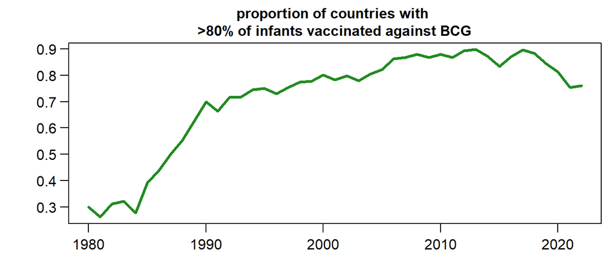

```r
plot(year, colMeans(arrayvacc[,,"BCG"]>80, na.rm=TRUE), type="l", lwd=3,
     col="forestgreen", ylab="",
     main="proportion of countries with \n>80% of infants vaccinated against BCG")
```

Note: the 80% selection should be reasoned for, just choosing something here.

- visualize into a pdf where you can scroll through the countries (use non-scrolling single-page view)

```r
pdf("vaccines_over_time.pdf")
par(mar=c(2,3,2,0.2), las=1)
rownames(countries) <- countries$iso3
vcolors <- c(berryFunctions::catPal(), "black", "blue")
# plot(1:14, pch=16, cex=3, col=vcolors)
for(c in dimnames(arrayvacc)$country) # PRK removed, loop over this
  {
  plot(year, year, type="n", ylim=c(0,100), yaxs="i", xlim=c(1981, 2025),
       main=paste(c, "-", countries[c,"country"]))
  for(v in 1:14) lines(year, arrayvacc[c,,v], col=vcolors[v])
  text(2022.5, arrayvacc[c,"2022",], names(arrayvacc[c,"2022",]), col=vcolors, adj=0)
  }
dev.off()
```

```r
berryFunctions::openFile("vaccines_over_time.pdf")
```

If wanted, you can also provide a shiny App with an interactive viewer of the raw data

## pipeline

- How should you structure your code?

codefiles: see the [2025-05-27: Coding Tips & Tricks](https://open.hpi.de/courses/hpi-dh-wearables2025/items/2ZzYqSKJovzhA3VS1pEor) lesson  
unified approach  
think ahead  
use good software approaches / principles

- Where can you deploy your code results (for free)?

github: readme generated from Qmd document as in [our git example](https://github.com/brry/weatherReport)  
github.io: [map example](https://brry.github.io/sewekow/) with [R script](https://github.com/brry/sewekow/blob/main/karte.R) creating `index.html`  
shinyapps.io: [example](https://brry.shinyapps.io/wetter/) with source code listed in-app